# Project Update 2

Group 3

### Motivation

You’re alone on cold dark night in an unfamiliar area. Your car is out of sight parked blocks away. You want to call your mom, a friend anyone, but the fear of being branded *‘a scaredy cat’* grips you. The term is one which has haughted you the protagonist in this story since childhood. Luckily you have a model one which is able to predict the probability of experiencing a crime while on route to your car given. The model will need to be provided the following information. The following script will discuss these and other interesting findings.

• Latitude: location window will be in

• Longitude: location window will be in

• Date: Will be used to extrapolate day of week, month of year

• Duration: window of time a cime may occure

### Questions

1. Does age play a role in crime statistics?
2. Does Income Play a role in crime statistics?
3. Does divorce play a role in crime statistics?
4. What is the probability you will experience a crime while traveling to your car?

### Import Dataset

Let us begin by importing our dataset aggergated across several different sources outlined at bottom of the notebook. In short our table consists of demographic, general location and crime statistics. To simplify the code I performed the joins prior across all the datasets. • 878,049 Records • 63 Columns

```r
# Read In file
df = read.csv('C:/Users/Alex Geiger/Desktop/School Project/clean_tbl.csv')

# Print row and column data
print(paste('Number of rows: ',nrow(df))); print(paste('Number of cols: ',ncol(df)))
```

```
## [1] "Number of rows:  878049"
```

```
## [1] "Number of cols:  63"
```

### Create Date Features

```r
# Create our date vector
df$Dates_crime  <- as.Date(df$Dates_crime)
df$hrs        <- hour(df$Dates_crime)    # calculate hours row
df$norm_date    <- df$Dates_crime - min(df$Dates_crime) # setup normalized date
df$norm_date    <- as.integer(df$norm_date)             # get integer in days
```

### Analysis of Crime Occurrences

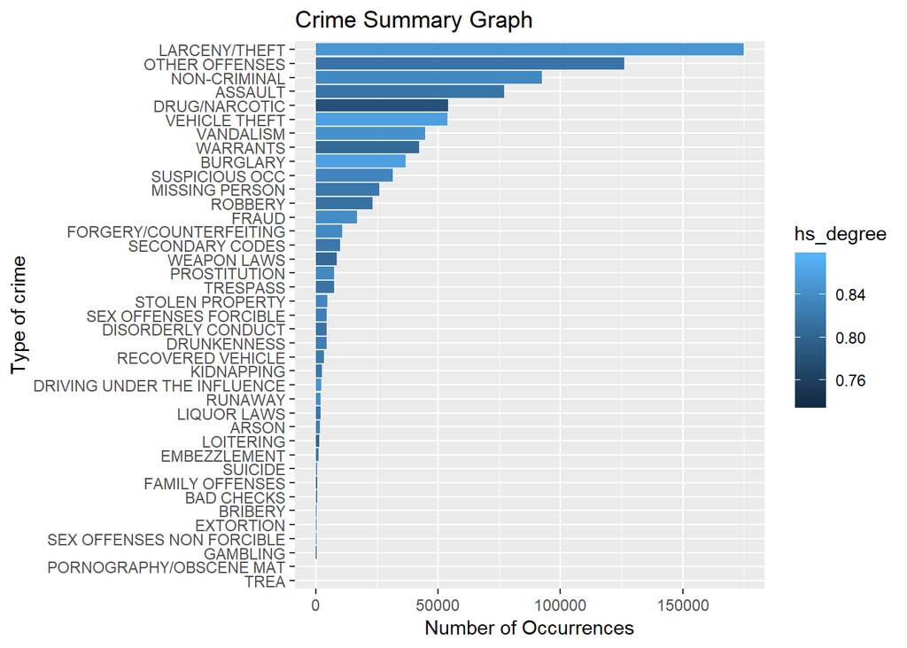

### Crimes We Are Looking

Inorder to look at all that we wish to avoid we must narrow down the potential outcomes by looking at key words in the crime description rather than just a Category of crime which enlightens us to what is really going on. These key words encapsulate our greatest fears lurking beyond the shadows of this erie night.

```r
# change factor to string
df$Descript_crime <- as.character(df$Descript_crime)

# may wish to include later 'MENTAL DISTURBED'
df <- df %>%
  filter(Descript_crime %like% 'HOMICIDE' | Descript_crime %like%  'GANG ACTIVITY' | Descript_crime %like% 'SHOOTING' | Descript_crime %like% 'GUN' | Descript_crime %like% 'KNIFE' | Descript_crime %like% 'DEADLY WEAPON') %>% filter( Category_crime !='NON-CRIMINAL' & Category_crime !='WEAPON LAWS')
```

### Geo Plot & Field Names

Let’s get an idea of where these crimes have occured by ploting them using leaflet which has many advantages over ggplot. After we will at the field names in the dataset. Any feild name starting with *m_* relates to male stats. Likewise any field name starting with *f_* relates to females.

[interactive chart not shown]

```
## [1] "List of Data Frame Fields:"
```

```
## [1] ""
```

```
##  [1] "Dates_crime"             "Category_crime"
##  [3] "Descript_crime"          "DayOfWeek_crime"
##  [5] "PdDistrict_crime"        "Resolution_crime"
##  [7] "Address_crime"           "X_crime"
##  [9] "Y_crime"                 "STUSAB"
## [11] "SUMLEVEL"                "STATE_Code"
## [13] "COUNTY_Code"             "state"
## [15] "ALand"                   "AWater"
## [17] "lat"                     "lng"
## [19] "NCESSCH"                 "GEOID"
## [21] "county"                  "coubsum"
## [23] "place"                   "MZIP"
## [25] "area_code"               "MCITY"
## [27] "pct_own"                 "rent_pct_hi_cdf"
## [29] "pop_den"                 "pop_pure"
```

[output cut: 18 more lines]

### Analysis of Crime Occurrences

In the graph we see forceible sexual offenses to be very rare so when looking into these statistics it should be noted the event happening is very unlikely. In addition we see Assults lead the way in crime and have a somewhat lower average highschool graduation rate.

[figure not shown]

### Analysis of Crime Occurrences

In the graph we see forceible sexual offenses to be very rare so when looking into these statistics it should be noted the event happening is very unlikely. In addition we see Assults lead the way in crime and have a somewhat lower average highschool graduation rate.

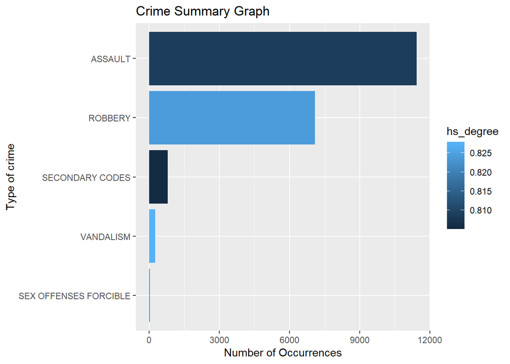

### Zip Code Location By Crime & Income

In the graph we connect the instance of our greatest fears experienced by some other unknown to us and median income. The connection between income and crime is clear and if we ever so happen to find ourself in the Zip Code 94102 you better think twice before strolling through the unforgiving night else you may share the fate of those whom found themselves standing face to face with their worst nightmare.

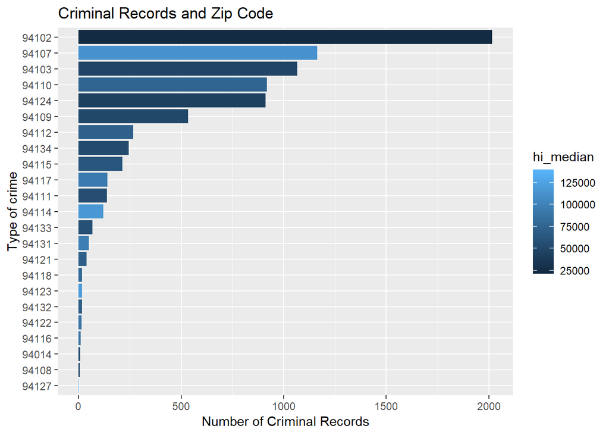

# Diving Deeper Into Income

We see when it comes to assult your in luck if you happen to find yourself in a good part of town. However, when it comes to rape a slightly different story but only slightly because the sample for these events are incredibly small. Now, how does the day of the week play a role in crime.

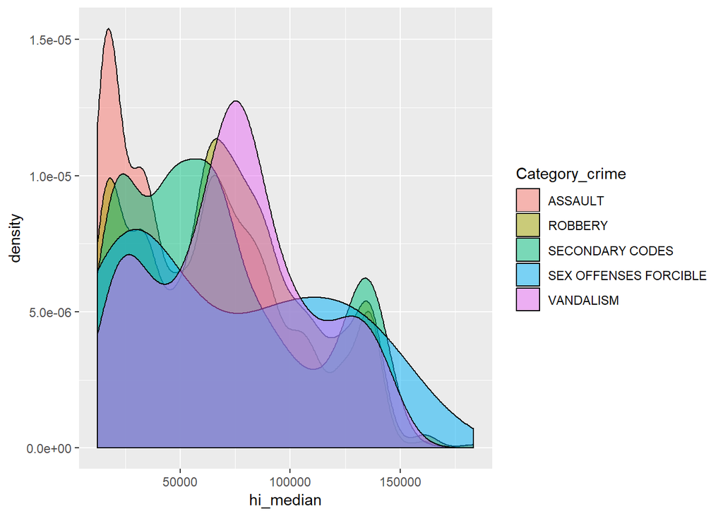

# Income & Day Of Week

In the following heatmap we can speculate two things. First, secondary Codes which is comprised of the things no city would wish to list including Homicide and Gang Activity. In our graph we see saturday the average income plumets which I suspect to be caused by gang on gang crime in low income area’s. Perhaps this is where the gang hangout hotspots a place where you must likely wish to never find yourself. Second, we see vandalism goes off the chars in Higher income areas. Perhapse this is a result of kids being kids in a way no neighbor enjoys.

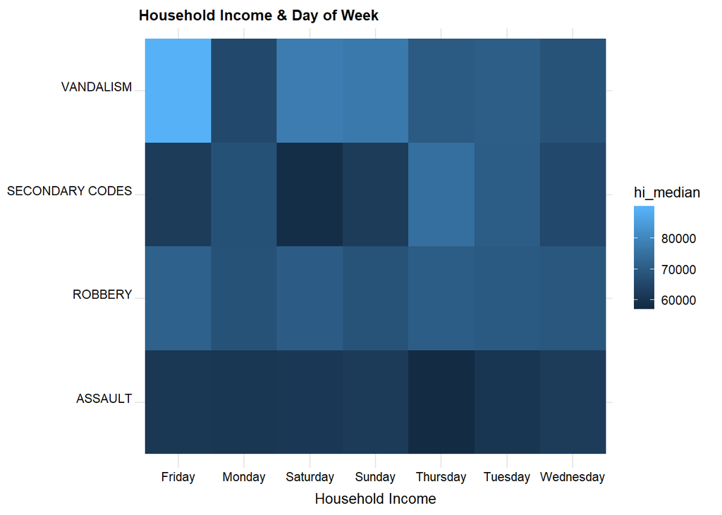

# Graduation Rates & Age & Crime

Here is the first time we look at our target features which is defined as the probability you will experience a crime on any day with no particularity. The data suggests middle class families with a good education and not enough to live behind the walls of gated community are at the highest risk of experiencing a crime.

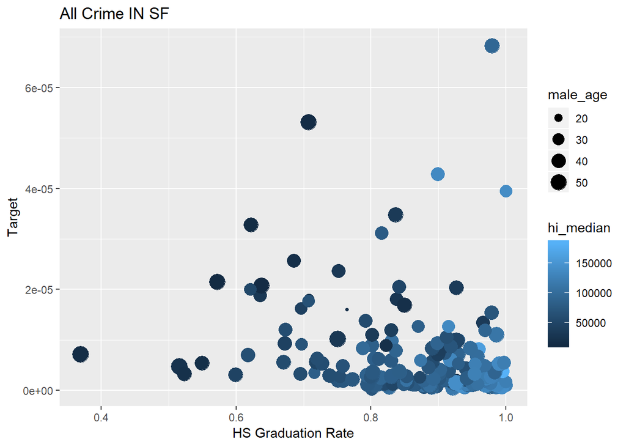

# What is the worst age?

From the bar chart we see the worst age to be is around 51 and uneducated and it’s easy to see why this may be the case. For instance, the uneducated edlerly are easy prey for the savage animals looking to steal what little time and money they have while they are only looking to live out their last few years of life in peace.

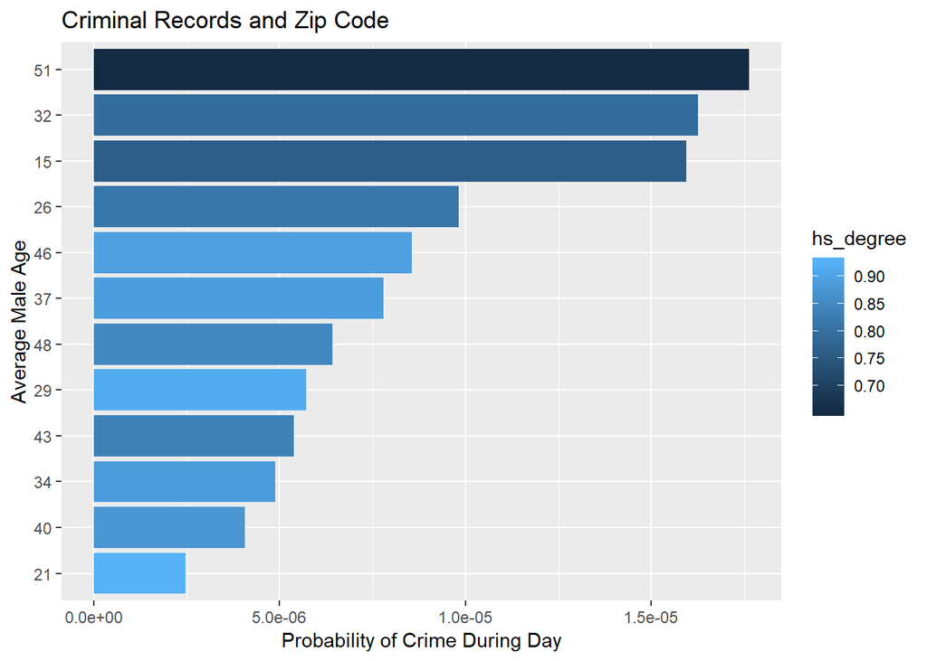

### Divorce, Crime & Not In The Laborforce Analysis

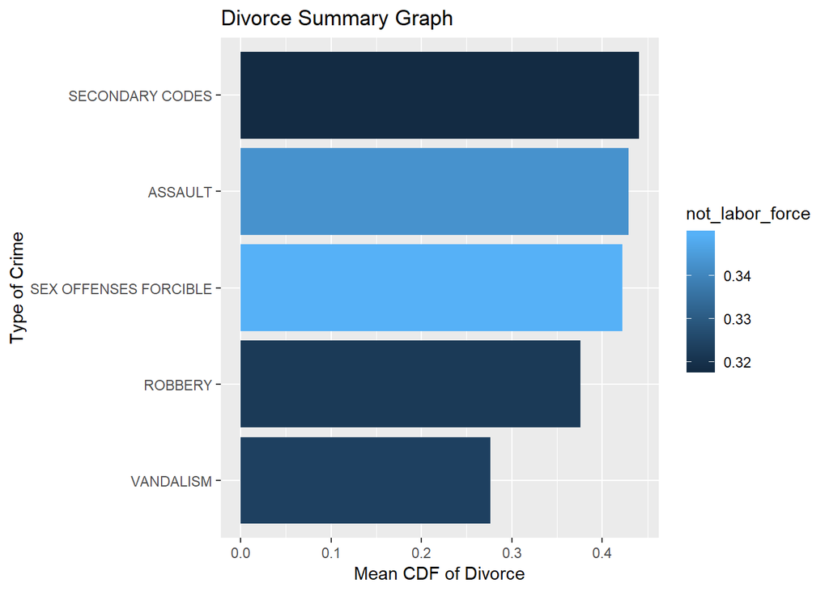

### Education, Crime & Unemployed

From the graph is all series crime has roughly the same highschool graduation rate expectation. However, we also see severe secondary crimes and unemployment go hand and hand.We see this may be very helpful while determining whether an area is or isn’t save.

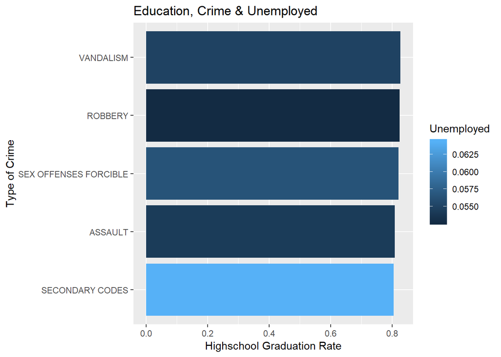

### What exactly is a gambling Crime?

```
## character(0)
```

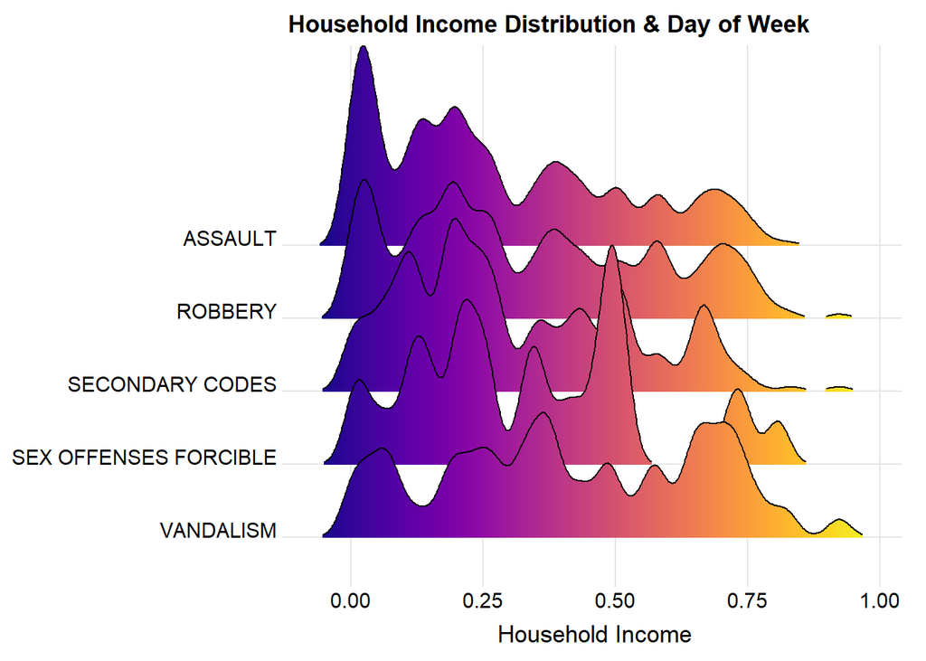

### Percent Home Ownership

The following graph shows the 2D density plot between the log of house hold median income and the log of percent home owner ship.

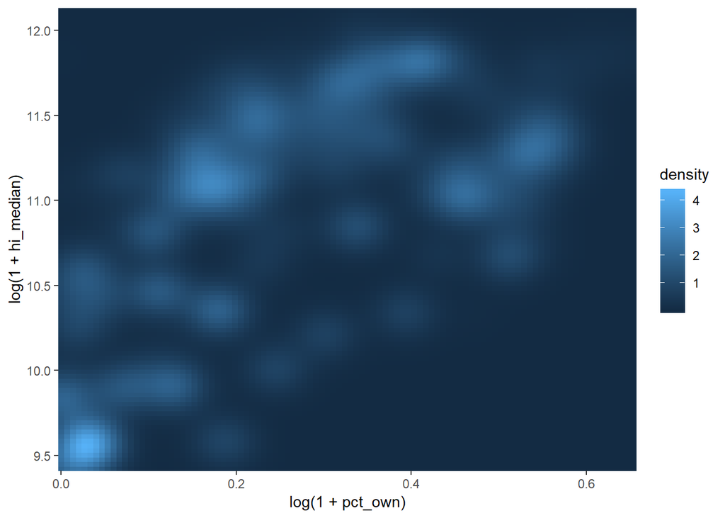

### More Questions

One of the things group three is particularly interested in looking into is how divorce rates, graduation rates and other factors effect on crime. In the following notebook we provide an overview into graduation rates and divorce rates.

### Conclution

We have a few more fields interesting fields we can dive into such as income, debt and other key factors which will be outlined in Project Summary Part II.

# Removed Work

### Preface & Objective

Our objective is to create a model which predicts the probability an individual will experience a crime. The dependent user inputs entered into our model will consist of Latitude, Longitude, Date, Duration. The output will be a vector with elements representing the Multi-class probabilities of our target crime classes. Note, other features will be used as well and extrapolated using the provided Latitude, Longitude, Date.

The following data was aggregated over the following sources:

• Targets uses the San Francisco from https://www.kaggle.com/c/sf-crime

• NCESSCH education data

• Gazetteer Files

• All other data used 5 Yr. ACS data

Note: The NYC data was not used because I found it to be only aggregate data.